# Tugas Pekan tiga

Radhitya Harma

## Impor Data

```r
library(rio)
datafossil <- rio::import("https://raw.githubusercontent.com/RadhityaHarma12/MPDW/main/Pertemuan%203/Data%20Minggu%203.csv")
str(datafossil)
```

```
## 'data.frame':    53 obs. of  4 variables:
##  $ t     : int  1 2 3 4 5 6 7 8 9 10 ...
##  $ Yt    : num  1.78 1.95 2.01 1.93 2.14 2.06 2.31 2.35 2.43 2.45 ...
##  $ Y(t-1): num  NA 1.78 1.95 2.01 1.93 2.14 2.06 2.31 2.35 2.43 ...
##  $ Xt    : int  44274 43698 44872 45006 47810 47417 49926 50319 51917 52850 ...
```

```r
datafossil
```

```
##     t   Yt   Y(t-1)    Xt
## 1   1 1.78       NA 44274
## 2   2 1.95     1.78 43698
## 3   3 2.01     1.95 44872
## 4   4 1.93     2.01 45006
## 5   5 2.14     1.93 47810
## 6   6 2.06     2.14 47417
## 7   7 2.31     2.06 49926
## 8   8 2.35     2.31 50319
## 9   9 2.43     2.35 51917
## 10 10 2.45     2.43 52850
## 11 11 2.45     2.45 51185
## 12 12 2.46     2.45 51556
## 13 13 2.42     2.46 51135
## 14 14 2.51     2.42 51920
```

[output cut: 39 more lines]

## Pembagian Data

```r
#SPLIT DATA
train<-datafossil[1:40,]
test<-datafossil[41:50,]
```

```r
#data time series
data.ts<-ts(datafossil)
train.ts<-ts(train)
test.ts<-ts(test)
```

## Model Koyck

Model Koyck didasarkan pada asumsi bahwa semakin jauh jarak lag peubah independen dari periode sekarang maka semakin kecil pengaruh peubah lag terhadap peubah dependen. Koyck mengusulkan suatu metode untuk menduga model dinamis distributed lag dengan mengasumsikan bahwa semua koefisien $\beta$ mempunyai tanda sama.

Model kyock merupakan jenis paling umum dari model infinite distributed lag dan juga dikenal sebagai geometric lag

$$y_t=a(1-\lambda)+\beta_0X_t+\beta_1Z_t+\lambda Y_{t-1}+V_t$$

dengan
$$V_t=u_t-\lambda
u_{t-1}$$

### Pemodelan

Pemodelan model Koyck dengan `R` dapat menggunakan `dLagM::koyckDlm()` . Fungsi `koyckDlm()` akan menerapkan model lag terdistribusi dengan transformasi Koyck satu prediktor. Nilai `x` dan `y` tidak perlu sebagai objek *time series* (`ts`). `intercept` dapat dibuat `TRUE` untuk memasukkan intersep ke dalam model.

```r
#MODEL KOYCK
model.koyck <- koyckDlm(x = train$Xt, y = train$Yt)
summary(model.koyck)
```

```
##
## Call:
## "Y ~ (Intercept) + Y.1 + X.t"
##
## Residuals:
##      Min       1Q   Median       3Q      Max
## -0.18500 -0.03498 -0.01046  0.04231  0.26826
##
## Coefficients:
##              Estimate Std. Error t value Pr(>|t|)
## (Intercept) 2.889e-01  2.056e-01   1.405   0.1685
## Y.1         7.839e-01  3.361e-01   2.333   0.0254 *
## X.t         5.181e-06  1.822e-05   0.284   0.7778
## ---
## Signif. codes:  0 '***' 0.001 '**' 0.01 '*' 0.05 '.' 0.1 ' ' 1
##
## Residual standard error: 0.0883 on 36 degrees of freedom
## Multiple R-Squared: 0.8987,  Adjusted R-squared: 0.8931
## Wald test: 157.7 on 2 and 36 DF,  p-value: < 2.2e-16
##
## Diagnostic tests:
## NULL
##
##                             alpha         beta       phi
## Geometric coefficients:  1.337025 5.180663e-06 0.7839354
```

```r
AIC(model.koyck)
```

```
## [1] -73.75486
```

```r
BIC(model.koyck)
```

```
## [1] -67.10061
```

### Peramalan dan Akurasi

Berikut adalah hasil peramalan y untuk 10 periode kedepan menggunakan model koyck

```r
fore.koyck <- forecast(model = model.koyck, x=test$Xt, h=10)
fore.koyck
```

```
## $forecasts
##  [1] 2.961562 3.023093 3.067724 3.074715 3.074047 3.035238 2.980444 2.925143
##  [9] 2.871451 2.808145
##
## $call
## forecast.koyckDlm(model = model.koyck, x = test$Xt, h = 10)
##
## attr(,"class")
## [1] "forecast.koyckDlm" "dLagM"
```

```r
mape.koyck <- MAPE(fore.koyck$forecasts, test$Yt)
#akurasi data training
GoF(model.koyck)
```

```
##              n       MAE          MPE       MAPE      sMAPE      MASE
## model.koyck 39 0.0621868 -0.001211088 0.02490659 0.02485336 0.9054017
##                     MSE     MRAE    GMRAE
## model.koyck 0.007196536 13610676 4.046138
```

## Regression with Distributed Lag

Pemodelan model Regression with Distributed Lag dengan `R` dapat menggunakan `dLagM::dlm()`. Fungsi `dlm()` akan menerapkan model lag terdistribusi dengan satu atau lebih prediktor. Nilai `x` dan `y` tidak perlu sebagai objek *time series* (`ts`). $q$ adalah integer yang mewakili panjang *lag* yang terbatas.

### Pemodelan (Lag=2)

```r
model.dlm <- dlm(x = train$Xt,y = train$Yt , q = 2)
summary(model.dlm)
```

```
##
## Call:
## lm(formula = model.formula, data = design)
##
## Residuals:
##       Min        1Q    Median        3Q       Max
## -0.261278 -0.057793  0.008789  0.049862  0.235583
##
## Coefficients:
##              Estimate Std. Error t value Pr(>|t|)
## (Intercept) 2.570e-01  1.882e-01   1.366 0.181024
## x.t         2.293e-05  5.336e-06   4.296 0.000137 ***
## x.1         7.093e-06  6.278e-06   1.130 0.266450
## x.2         1.210e-05  5.330e-06   2.269 0.029700 *
## ---
## Signif. codes:  0 '***' 0.001 '**' 0.01 '*' 0.05 '.' 0.1 ' ' 1
##
## Residual standard error: 0.1136 on 34 degrees of freedom
## Multiple R-squared:  0.8177, Adjusted R-squared:  0.8016
## F-statistic: 50.82 on 3 and 34 DF,  p-value: 1.178e-12
##
## AIC and BIC values for the model:
##         AIC       BIC
## 1 -51.69171 -43.50378
```

```r
AIC(model.dlm)
```

```
## [1] -51.69171
```

```r
BIC(model.dlm)
```

```
## [1] -43.50378
```

### Peramalan dan Akurasi

Berikut merupakan hasil peramalan $y$ untuk 10 periode kedepan

```r
fore.dlm <- forecast(model = model.dlm, x=test$Xt, h=10)
fore.dlm
```

```
## $forecasts
##  [1] 3.199437 3.404178 3.527038 3.465813 3.391853 3.148649 2.974036 2.796647
##  [9] 2.677084 2.540224
##
## $call
## forecast.dlm(model = model.dlm, x = test$Xt, h = 10)
##
## attr(,"class")
## [1] "forecast.dlm" "dLagM"
```

```r
mape.dlm <- MAPE(fore.dlm$forecasts, test$Yt)
#akurasi data training
GoF(model.dlm)
```

```
##            n       MAE          MPE       MAPE      sMAPE     MASE        MSE
## model.dlm 38 0.0809481 -0.002060057 0.03171244 0.03156714 1.174541 0.01154684
##               MRAE    GMRAE
## model.dlm 59599198 4.999522
```

### *Lag* Optimum

```r
#penentuan lag optimum
finiteDLMauto(formula = Yt ~ Xt,
              data = data.frame(train), q.min = 1, q.max = 6,
              model.type = "dlm", error.type = "AIC", trace = FALSE)
```

```
##   q - k    MASE       AIC       BIC   GMRAE   MBRAE R.Adj.Sq  Ljung-Box
## 6     6 0.86036 -63.16668 -49.42943 4.56107 0.61008  0.79675 0.03337438
```

Berdasarkan output tersebut, lag optimum didapatkan ketika lag=6. Selanjutnya dilakukan pemodelan untuk lag=6

```r
#model dlm dengan lag optimum
model.dlm2 <- dlm(x = train$Xt,y = train$Yt , q = 6)
summary(model.dlm2)
```

```
##
## Call:
## lm(formula = model.formula, data = design)
##
## Residuals:
##      Min       1Q   Median       3Q      Max
## -0.28059 -0.03781  0.01076  0.02453  0.16989
##
## Coefficients:
##               Estimate Std. Error t value Pr(>|t|)
## (Intercept)  3.342e-01  2.056e-01   1.626  0.11611
## x.t          1.493e-05  4.832e-06   3.090  0.00472 **
## x.1          3.040e-06  5.680e-06   0.535  0.59707
## x.2          3.254e-06  4.821e-06   0.675  0.50571
## x.3          6.450e-06  4.947e-06   1.304  0.20371
## x.4         -1.527e-07  4.855e-06  -0.031  0.97515
## x.5          9.279e-06  6.108e-06   1.519  0.14077
## x.6          5.030e-06  5.570e-06   0.903  0.37472
## ---
## Signif. codes:  0 '***' 0.001 '**' 0.01 '*' 0.05 '.' 0.1 ' ' 1
##
## Residual standard error: 0.08387 on 26 degrees of freedom
## Multiple R-squared:  0.8399, Adjusted R-squared:  0.7968
## F-statistic: 19.48 on 7 and 26 DF,  p-value: 7.639e-09
##
## AIC and BIC values for the model:
##         AIC       BIC
## 1 -63.16668 -49.42943
```

```r
AIC(model.dlm2)
```

```
## [1] -63.16668
```

```r
BIC(model.dlm2)
```

```
## [1] -49.42943
```

Adapun hasil peramalan 10 periode kedepan menggunakan model tersebut adalah sebagai berikut

```r
#peramalan dan akurasi
fore.dlm2 <- forecast(model = model.dlm2, x=test$Xt, h=10)
mape.dlm2<- MAPE(fore.dlm2$forecasts, test$Yt)
#akurasi data training
GoF(model.dlm2)
```

```
##             n        MAE           MPE      MAPE      sMAPE      MASE
## model.dlm2 34 0.05031777 -0.0007147412 0.0190036 0.01890403 0.8603557
##                    MSE     MRAE    GMRAE
## model.dlm2 0.005379648 43059420 4.561074
```

## Model Autoregressive

Peubah dependen dipengaruhi oleh peubah independen pada waktu sekarang, serta dipengaruhi juga oleh peubah dependen itu sendiri pada satu waktu yang lalu maka model tersebut disebut *autoregressive* (Gujarati 2004).

### Pemodelan

Pemodelan Autoregressive dilakukan menggunakan fungsi `dLagM::ardlDlm()` . Fungsi tersebut akan menerapkan *autoregressive* berordo $(p,q)$ dengan satu prediktor. Dengan $p$ adalah integer yang mewakili panjang *lag* yang terbatas dan $q$ adalah integer yang merepresentasikan ordo dari proses *autoregressive*.

```r
model.ardl <- ardlDlm(x = train$Xt, y = train$Yt, p = 1 , q = 1)
summary(model.ardl)
```

```
##
## Time series regression with "ts" data:
## Start = 2, End = 40
##
## Call:
## dynlm(formula = as.formula(model.text), data = data, start = 1)
##
## Residuals:
##       Min        1Q    Median        3Q       Max
## -0.232814 -0.027259 -0.006647  0.049927  0.208615
##
## Coefficients:
##               Estimate Std. Error t value Pr(>|t|)
## (Intercept)  2.454e-01  1.336e-01   1.837   0.0748 .
## X.t          1.158e-05  4.699e-06   2.464   0.0188 *
## X.1         -1.700e-06  4.948e-06  -0.344   0.7332
## Y.1          6.985e-01  1.186e-01   5.889 1.08e-06 ***
## ---
## Signif. codes:  0 '***' 0.001 '**' 0.01 '*' 0.05 '.' 0.1 ' ' 1
##
## Residual standard error: 0.08727 on 35 degrees of freedom
## Multiple R-squared:  0.9038, Adjusted R-squared:  0.8956
## F-statistic: 109.6 on 3 and 35 DF,  p-value: < 2.2e-16
```

```r
AIC(model.ardl)
```

```
## [1] -73.76618
```

```r
BIC(model.ardl)
```

```
## [1] -65.44837
```

### Peramalan dan Akurasi

```r
fore.ardl <- forecast(model = model.ardl, x=test$Xt, h=10)
fore.ardl
```

```
## $forecasts
##  [1] 3.030239 3.157992 3.229672 3.218367 3.205915 3.113686 3.007372 2.913520
##  [9] 2.828909 2.725796
##
## $call
## forecast.ardlDlm(model = model.ardl, x = test$Xt, h = 10)
##
## attr(,"class")
## [1] "forecast.ardlDlm" "dLagM"
```

Data di atas merupakan hasil peramalan untuk 10 periode ke depan menggunakan Model Autoregressive dengan $p=1$ dan $q=1$.

```r
mape.ardl <- MAPE(fore.ardl$forecasts, test$Yt)
mape.ardl
```

```
## [1] 0.02848071
```

```r
#akurasi data training
GoF(model.ardl)
```

```
##             n        MAE          MPE       MAPE      sMAPE      MASE
## model.ardl 39 0.05944654 -0.001149379 0.02379995 0.02368309 0.8655051
##                    MSE     MRAE    GMRAE
## model.ardl 0.006834802 10819947 3.543454
```

Berdasarkan akurasi di atas, terlihat bahwa nilai MAPE keduanya tidak jauh berbeda yakni 0.02848071 dan 0.02379995. Artinya, model regresi dengan distribusi ini tidak `overfitted` atau `underfitted`

### *Lag* Optimum

```r
#penentuan lag optimum
model.ardl.opt <- ardlBoundOrders(data = data.frame(datafossil), ic = "AIC",
                                  formula = Yt ~ Xt )
min_p=c()
for(i in 1:6){
  min_p[i]=min(model.ardl.opt$Stat.table[[i]])
}
q_opt=which(min_p==min(min_p, na.rm = TRUE))
p_opt=which(model.ardl.opt$Stat.table[[q_opt]] ==
              min(model.ardl.opt$Stat.table[[q_opt]], na.rm = TRUE))
data.frame("q_optimum" = q_opt, "p_optimum" = p_opt,
           "AIC"=model.ardl.opt$min.Stat)
```

```
##   q_optimum p_optimum       AIC
## 1         1         1 -152.4879
```

Dari tabel di atas, dapat terlihat bahwa nilai AIC terendah didapat ketika $p=1$ dan $q=1$, yaitu sebesar -152.5. Artinya, model autoregressive optimum didapat ketika $p=1$ dan $q=1$.

Selanjutnya dapat dilakukan pemodelan dengan nilai $p$ dan $q$ optimum seperti inisialisasi di langkah sebelumnya.

## Pemodelan DLM & ARDL dengan Library `dynlm`

Pemodelan regresi dengan peubah *lag* tidak hanya dapat dilakukan dengan fungsi pada *packages* `dLagM` , tetapi terdapat *packages* `dynlm` yang dapat digunakan. Untuk menentukan `formula` model yang akan digunakan, tersedia fungsi tambahan yang memungkinkan spesifikasi dinamika (melalui `d()` dan `L()`) atau pola linier/siklus dengan mudah (melalui `trend()`, `season()`, dan `harmon()`). Semua fungsi formula baru mengharuskan argumennya berupa objek deret waktu (yaitu, `"ts"` atau `"zoo"`).

```r
#sama dengan model dlm q=1
cons_lm1 <- dynlm(Yt ~ Xt+L(Xt),data = train.ts)
#sama dengan model ardl p=1 q=0
cons_lm2 <- dynlm(Yt ~ Xt+L(Yt),data = train.ts)
#sama dengan ardl p=1 q=1
cons_lm3 <- dynlm(Yt ~ Xt+L(Xt)+L(Yt),data = train.ts)
#sama dengan dlm p=2
cons_lm4 <- dynlm(Yt ~ Xt+L(Xt)+L(Xt,2),data = train.ts)
```

### Ringkasan Model

```r
summary(cons_lm1)
```

```
##
## Time series regression with "ts" data:
## Start = 2, End = 40
##
## Call:
## dynlm(formula = Yt ~ Xt + L(Xt), data = train.ts)
##
## Residuals:
##       Min        1Q    Median        3Q       Max
## -0.292546 -0.063384 -0.001613  0.048767  0.218497
##
## Coefficients:
##              Estimate Std. Error t value Pr(>|t|)
## (Intercept) 2.762e-01  1.858e-01   1.487  0.14580
## Xt          2.622e-05  5.547e-06   4.727 3.45e-05 ***
## L(Xt)       1.532e-05  5.588e-06   2.741  0.00948 **
## ---
## Signif. codes:  0 '***' 0.001 '**' 0.01 '*' 0.05 '.' 0.1 ' ' 1
##
## Residual standard error: 0.1214 on 36 degrees of freedom
## Multiple R-squared:  0.8085, Adjusted R-squared:  0.7978
## F-statistic: 75.99 on 2 and 36 DF,  p-value: 1.202e-13
```

```r
summary(cons_lm2)
```

```
##
## Time series regression with "ts" data:
## Start = 2, End = 40
##
## Call:
## dynlm(formula = Yt ~ Xt + L(Yt), data = train.ts)
##
## Residuals:
##       Min        1Q    Median        3Q       Max
## -0.227543 -0.028320 -0.007167  0.052271  0.214033
##
## Coefficients:
##              Estimate Std. Error t value Pr(>|t|)
## (Intercept) 2.353e-01  1.288e-01   1.828   0.0759 .
## Xt          1.117e-05  4.491e-06   2.487   0.0177 *
## L(Yt)       6.747e-01  9.509e-02   7.095 2.46e-08 ***
## ---
## Signif. codes:  0 '***' 0.001 '**' 0.01 '*' 0.05 '.' 0.1 ' ' 1
##
## Residual standard error: 0.08619 on 36 degrees of freedom
## Multiple R-squared:  0.9035, Adjusted R-squared:  0.8981
## F-statistic: 168.5 on 2 and 36 DF,  p-value: < 2.2e-16
```

```r
summary(cons_lm3)
```

```
##
## Time series regression with "ts" data:
## Start = 2, End = 40
##
## Call:
## dynlm(formula = Yt ~ Xt + L(Xt) + L(Yt), data = train.ts)
##
## Residuals:
##       Min        1Q    Median        3Q       Max
## -0.232814 -0.027259 -0.006647  0.049927  0.208615
##
## Coefficients:
##               Estimate Std. Error t value Pr(>|t|)
## (Intercept)  2.454e-01  1.336e-01   1.837   0.0748 .
## Xt           1.158e-05  4.699e-06   2.464   0.0188 *
## L(Xt)       -1.700e-06  4.948e-06  -0.344   0.7332
## L(Yt)        6.985e-01  1.186e-01   5.889 1.08e-06 ***
## ---
## Signif. codes:  0 '***' 0.001 '**' 0.01 '*' 0.05 '.' 0.1 ' ' 1
##
## Residual standard error: 0.08727 on 35 degrees of freedom
## Multiple R-squared:  0.9038, Adjusted R-squared:  0.8956
## F-statistic: 109.6 on 3 and 35 DF,  p-value: < 2.2e-16
```

```r
summary(cons_lm4)
```

```
##
## Time series regression with "ts" data:
## Start = 3, End = 40
##
## Call:
## dynlm(formula = Yt ~ Xt + L(Xt) + L(Xt, 2), data = train.ts)
##
## Residuals:
##       Min        1Q    Median        3Q       Max
## -0.261278 -0.057793  0.008789  0.049862  0.235583
##
## Coefficients:
##              Estimate Std. Error t value Pr(>|t|)
## (Intercept) 2.570e-01  1.882e-01   1.366 0.181024
## Xt          2.293e-05  5.336e-06   4.296 0.000137 ***
## L(Xt)       7.093e-06  6.278e-06   1.130 0.266450
## L(Xt, 2)    1.210e-05  5.330e-06   2.269 0.029700 *
## ---
## Signif. codes:  0 '***' 0.001 '**' 0.01 '*' 0.05 '.' 0.1 ' ' 1
##
## Residual standard error: 0.1136 on 34 degrees of freedom
## Multiple R-squared:  0.8177, Adjusted R-squared:  0.8016
## F-statistic: 50.82 on 3 and 34 DF,  p-value: 1.178e-12
```

### SSE

```r
deviance(cons_lm1)
```

```
## [1] 0.5307212
```

```r
deviance(cons_lm2)
```

```
## [1] 0.2674562
```

```r
deviance(cons_lm3)
```

```
## [1] 0.2665573
```

```r
deviance(cons_lm4)
```

```
## [1] 0.4387801
```

## Perbandingan Model

```r
akurasi <- matrix(c(mape.koyck, mape.dlm, mape.dlm2, mape.ardl))
row.names(akurasi)<- c("Koyck","DLM 1","DLM 2","Autoregressive")
colnames(akurasi) <- c("MAPE")
akurasi
```

```
##                      MAPE
## Koyck          0.03565395
## DLM 1          0.07803275
## DLM 2          0.05794675
## Autoregressive 0.02848071
```

Berdasarkan nilai MAPE, model paling optimum didapat pada Model Autoregressive karena memiliki nilai MAPE yang terkecil sebesar 2.85%.

### Plot

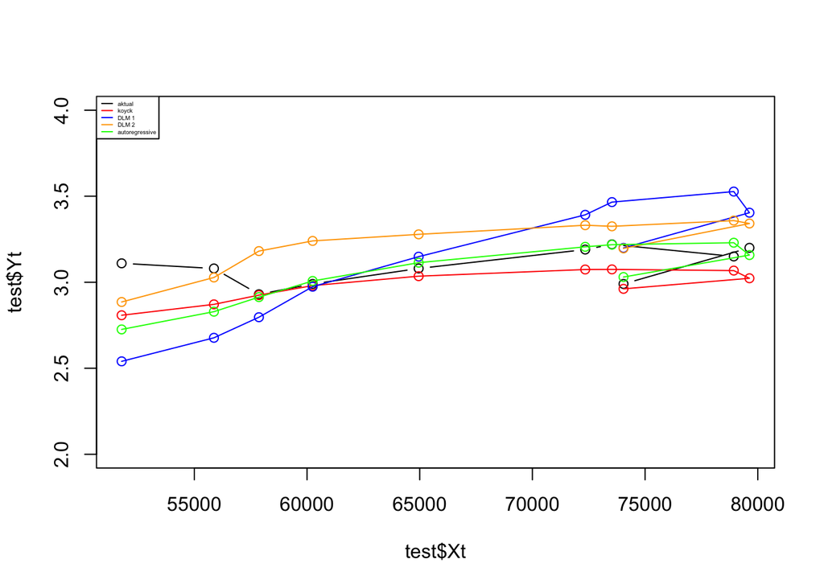

```r
par(mfrow=c(1,1))
plot(test$Xt, test$Yt, type="b", col="black", ylim=c(2,4))
points(test$Xt, fore.koyck$forecasts,col="red")
lines(test$Xt, fore.koyck$forecasts,col="red")
points(test$Xt, fore.dlm$forecasts,col="blue")
lines(test$Xt, fore.dlm$forecasts,col="blue")
points(test$Xt, fore.dlm2$forecasts,col="orange")
lines(test$Xt, fore.dlm2$forecasts,col="orange")
points(test$Xt, fore.ardl$forecasts,col="green")
lines(test$Xt, fore.ardl$forecasts,col="green")
legend("topleft",c("aktual", "koyck","DLM 1","DLM 2", "autoregressive"), lty=1, col=c("black","red","blue","orange","green"), cex=0.3)
```

Berdasarkan plot tersebut, terlihat bahwa plot yang paling mendekati data aktualnya adalah Model Autoregressive, sehingga dapat disimpulkan model terbaik dalam hal ini adalah model Autoregressive. Pada model Autoregressive juga memiliki nilai MAPE yang paling kecil diantara model lainnya. Maka, untuk itu akan digunakan model Autoregressive sebab memiliki plot yang mendekati data aktual dan nilai MAPE yang terkecil.